# Reducción de dimensión: PC - Proyecto modulo 6

Eumir Rendon, Raúl Llamosas, etc

2026-06-23

```r
# library(learnr)
library(tidyverse)
library(tidymodels)
library(embed)
library(corrr)
library(tidytext)
library(gradethis)
library(sortable)
library(learntidymodels)
library(rstatix)
```

```r
library(broom)
library(rgl)
library(plotly)
library(GGally)
library(tidyr)
library(FactoMineR)
library(factoextra)
library(ggord)
library(modeldata)
library(tsne)
library(uwot)
library(scattermore)
library(readr)
library(Rtsne)
library(gganimate)
library(data.table)
library(baguette)
library(discrim)
theme_set(theme_bw(16))

tidymodels_prefer()

df<-read.csv("/home/yamorza/Documentos/espacio_trabajo_intro_analisis_dat2/proyecto_modulo_6/src/habits.csv")
```

Comenzaremos con nuestra reduccion PCA

```r
wdbc_recipe <- recipe(~ ., data = df) %>%
  step_dummy(all_nominal_predictors()) %>%
  step_normalize(all_predictors()) %>%
  step_pca(all_predictors(), id = "pca")

wdbc_pca <- prep(wdbc_recipe)

# pca_loading <- tidy(wdbc_pca, id="pca")
# pca_loading

# pca_variances <- tidy(wdbc_pca, id = "pca", type = "variance")
# pca_variances

pca_var_percent<- tidy(wdbc_pca, id = "pca", type = "variance")%>%
                filter(str_detect(terms, "percent variance"))
pca_var_percent
```

```
## # A tibble: 40 × 4
##    terms            value component id
##    <chr>            <dbl>     <int> <chr>
##  1 percent variance  9.78         1 pca
##  2 percent variance  7.45         2 pca
##  3 percent variance  7.37         3 pca
##  4 percent variance  6.72         4 pca
##  5 percent variance  6.08         5 pca
##  6 percent variance  5.69         6 pca
##  7 percent variance  5.39         7 pca
##  8 percent variance  5.23         8 pca
##  9 percent variance  5.15         9 pca
## 10 percent variance  5.04        10 pca
## # ℹ 30 more rows
```

```r
pca_var_cum_percent<-tidy(wdbc_pca, id = "pca", type = "variance")%>%
                filter(str_detect(terms, "cumulative percent variance"))
pca_var_cum_percent
```

```
## # A tibble: 20 × 4
##    terms                        value component id
##    <chr>                        <dbl>     <int> <chr>
##  1 cumulative percent variance   9.78         1 pca
##  2 cumulative percent variance  17.2          2 pca
##  3 cumulative percent variance  24.6          3 pca
##  4 cumulative percent variance  31.3          4 pca
##  5 cumulative percent variance  37.4          5 pca
##  6 cumulative percent variance  43.1          6 pca
##  7 cumulative percent variance  48.5          7 pca
##  8 cumulative percent variance  53.7          8 pca
##  9 cumulative percent variance  58.9          9 pca
## 10 cumulative percent variance  63.9         10 pca
## 11 cumulative percent variance  68.9         11 pca
## 12 cumulative percent variance  73.8         12 pca
## 13 cumulative percent variance  78.6         13 pca
## 14 cumulative percent variance  83.3         14 pca
## 15 cumulative percent variance  87.6         15 pca
## 16 cumulative percent variance  91.5         16 pca
## 17 cumulative percent variance  94.5         17 pca
## 18 cumulative percent variance  97.4         18 pca
## 19 cumulative percent variance  99.7         19 pca
## 20 cumulative percent variance 100           20 pca
```

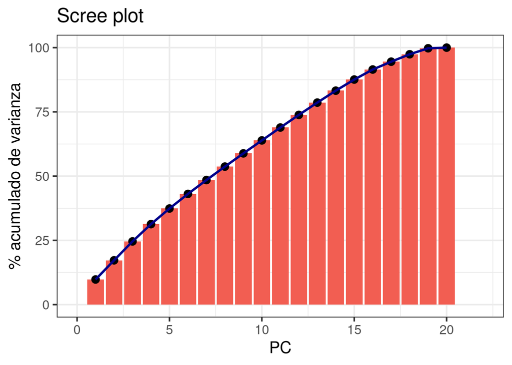

```r
wdbc_pca %>%
  tidy(id = "pca", type = "variance") %>%
  dplyr::filter(terms == "cumulative percent variance") %>%
  ggplot(aes(x = component, y = value)) +
  geom_col(fill = "#F25E52") +
  xlim(c(0, 22)) +
  geom_point(size=3) +
  geom_line(color="darkblue", size=1.1)+
  labs(x="PC", y="% acumulado de varianza", title="Scree plot")
```

Gracias a nuestro analisis podemos ver que en definitiva el metodo PCA no lograra reducir las dimensiones de forma eficiente, ya que de tomar 3 dimensiones apenas lograremos explicar el 25% de nuestra variabilidad, justamente siendo fundamentado con nuestras estadisticas anteriores

Veremos una grafica para nuestros dos primeros componentes

```r
variance_exp <- tidy(wdbc_pca,id = "pca", type = "variance")%>%
                filter(str_detect(terms, "percent variance"))
variance_exp
```

```
## # A tibble: 40 × 4
##    terms            value component id
##    <chr>            <dbl>     <int> <chr>
##  1 percent variance  9.78         1 pca
##  2 percent variance  7.45         2 pca
##  3 percent variance  7.37         3 pca
##  4 percent variance  6.72         4 pca
##  5 percent variance  6.08         5 pca
##  6 percent variance  5.69         6 pca
##  7 percent variance  5.39         7 pca
##  8 percent variance  5.23         8 pca
##  9 percent variance  5.15         9 pca
## 10 percent variance  5.04        10 pca
## # ℹ 30 more rows
```

```r
VE <- paste("Varianza explicada por dos componentes:"
                       ,round(variance_exp$value[[1]]+variance_exp$value[[2]], digits = 2),"%")
# VE

# Estos son los valores de cada componente para cada fila
datos_pca<-bake(wdbc_pca, new_data = NULL)
datos_pca
```

```
## # A tibble: 1,000 × 5
##       PC1     PC2     PC3     PC4    PC5
##     <dbl>   <dbl>   <dbl>   <dbl>  <dbl>
##  1  1.41  -0.100   1.45    1.18    0.593
##  2 -3.14  -0.284  -1.51   -0.529  -0.559
##  3  2.60  -3.06    1.27   -0.488   0.192
##  4  3.56   1.29    2.55   -0.0482  1.49
##  5  0.166  2.23    1.16    0.837   0.315
##  6 -2.82   1.14    1.45    2.15    1.18
##  7 -1.65  -0.0304  0.315   2.52   -0.508
##  8 -0.464  0.210  -0.0656  0.144  -0.143
##  9 -0.562  1.60   -0.123   0.145  -1.17
## 10 -2.46   1.04   -0.479  -0.363  -0.556
## # ℹ 990 more rows
```

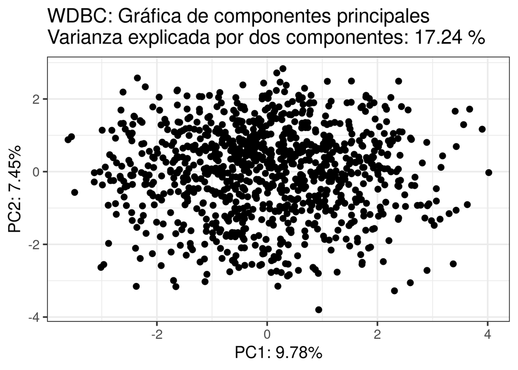

```r
datos_pca %>%
  ggplot(aes(x = PC1, y = PC2))+
  geom_point()+
  labs(x = paste0("PC1: ",round(variance_exp$value[[1]],2), "%"),
       y = paste0("PC2: ",round(variance_exp$value[[2]],2), "%"))+
  ggtitle(paste0("WDBC: Gráfica de componentes principales","\n",VE))
```

Como vemos precisamente no podemos encontrar grupos claros, aun asi trataremos de ver si nuestras suposiciones de la variable calificadora son ciertas, es decir que pueden ser declarados como una etiqueta, para ello dividiremos en 4 cuantiles las calificaciones del examen

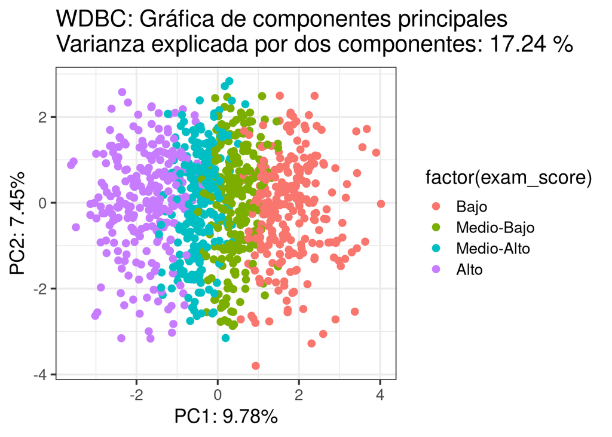

```r
datos_pca$exam_score <- df$exam_score

datos_pca_quantile <- datos_pca %>%
  mutate(exam_score = cut(
    exam_score,
    breaks = quantile(exam_score, probs = seq(0, 1, 0.25), na.rm = TRUE),
    include.lowest = TRUE,
    labels = c("Bajo", "Medio-Bajo", "Medio-Alto", "Alto")
  ))

datos_pca_quantile %>%
  ggplot(aes(x = PC1, y = PC2,color = factor(exam_score)))+
  geom_point()+
  labs(x = paste0("PC1: ",round(variance_exp$value[[1]],2), "%"),
       y = paste0("PC2: ",round(variance_exp$value[[2]],2), "%"))+
  ggtitle(paste0("WDBC: Gráfica de componentes principales","\n",VE))
```

Como podemos ver los datos son dispersos y pese a todo podemos ver cierta distribucion de nuestros datos gracias a nuestra reduccion de variable

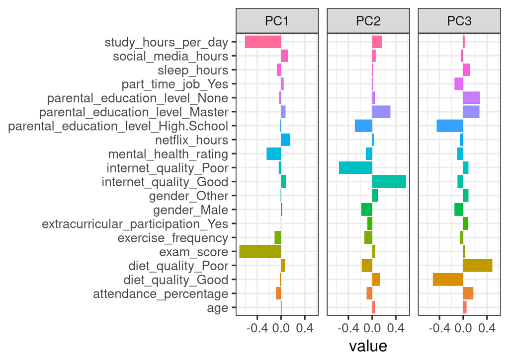

```r
wdbc_pca %>%
  tidy(id = "pca") %>%
  filter(component %in% paste0("PC", 1:3)) %>%
  mutate(component = fct_inorder(component)) %>%
  ggplot(aes(value, terms, fill = terms)) +
  geom_col(show.legend = FALSE) +
  facet_wrap(~component, nrow = 1) +
  labs(y = NULL)
```

Veremos que precisamente nuestro primer componente toma importancia en las horas de estudio y el resultado del examen, seguidos por factores como la calidad de internet y la calidad de la dieta

```r
plot3d(
  x=datos_pca_quantile$PC1, y=datos_pca_quantile$PC2, z=datos_pca_quantile$PC3,
  col = as.numeric(datos_pca_quantile$exam_score),
  type = 's',
  radius = .1,
  xlab="PC1", ylab="PC2", zlab="PC3")

g.df1 <- plot_ly(datos_pca_quantile, x = ~PC1, y = ~PC2, z = ~PC3, color = ~exam_score, colors =c("#0000FF", "#FF00FF") )
g.df1 <- g.df1 %>% add_markers()
g.df1 <- g.df1 %>% plotly::layout(scene = list(xaxis = list(title = 'PC1'),
                     yaxis = list(title = 'PC2'),
                     zaxis = list(title = 'PC3')))

g.df1
```

[interactive chart not shown]

Para el caso de 3 dimensiones no nos muestra un cambio significativo, sin embargo nuestra separacion por grupos sigue estando presente